# Notebook

**Research Question:** "For drug identification (judgement ②), how accurately does each model in the roster extract the drugs mentioned in a post — precision AND recall, against Opus-as-truth — and how do the models diverge?"

*Judgement ② of 11 · the factual template with a recall dimension: F1 vs the validated judge, a precision–recall map, an N×N divergence heatmap, and a price-aware scorecard. Numbers computed from the run.*

**Abstract.** Drug identification (judgement ②) reads a post and returns the *set* of drugs mentioned — `extract_batch`, the pipeline's second step. A missed drug is a lost treatment report; a hallucinated one is a phantom report. We test the roster the way the design specifies: **22 models** extract drugs from **40 posts** (temp 0), scored for **precision and recall against Opus-as-judge** (which reads the post, rules each extraction correct/hallucinated, and lists drugs everyone missed), with a string-in-post floor and an N×N divergence map beside it. **gpt-5-mini** has the best balance (F1=0.79); the roster splits into precise-but-cautious (grok-4.5, 99% precision) and thorough-but-eager (gpt-5-mini, 71% recall) extractors. The string-in-post floor is only a noisy corroborator (net -5% vs the judge): it misses correct abbreviations (LDN → "low dose naltrexone") and admits the odd non-treatment mention ("histamine" as a condition), so Opus-as-judge — reading for *treatment* mention and resolving abbreviations — is the standard, not the floor.

## 1. What this judgement is, and why correctness matters

`extract_batch` reads a post and returns the set of drugs, supplements, and treatments it mentions. Every downstream sentiment report is keyed to a drug this step found, so its errors bound the whole pipeline: a **missed** drug silently drops a treatment report; a **hallucinated** drug injects a phantom one. Because a post has a definite set of drugs, this is factual — measured by **precision** (are the extracted drugs really there?) and **recall** (did it find them all?), not agreement.

## 2. Two truth sources — and why the objective floor is not enough here

For ① alias, the objective source (RxNorm) missed valid informal aliases. For ② the objective source — does the extracted drug literally appear in the post? — is noisy in *both* directions: it misses correct abbreviations and paraphrases (a model extracting 'low dose naltrexone' from 'LDN'), and it counts drug names that appear as the author's **condition** rather than a treatment ('histamine issues'). Neither error dominates, so string-presence can't rank models — Opus-as-judge, which reads for *treatment* mention and resolves abbreviations, is the standard; the floor only corroborates.

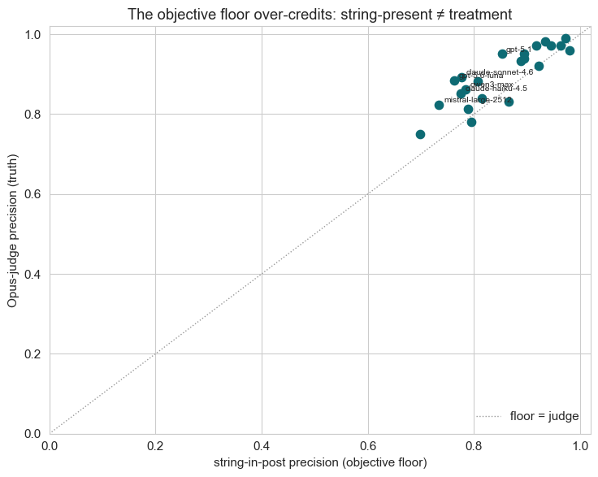

**What this shows:** the floor tracks the judge on average (net string − judge = -5%) but diverges case by case. **18** models sit above the diagonal — the judge credits correct abbreviations and paraphrases the literal string-match misses (e.g. 'low dose naltrexone' extracted from 'LDN'); **3** sit below, where the floor counts a drug name used as a condition, not a treatment ('histamine issues'). Neither cancels cleanly, so the string floor corroborates but cannot rank — the validated judge is the standard.

## 3. Correctness scorecard — the verdict

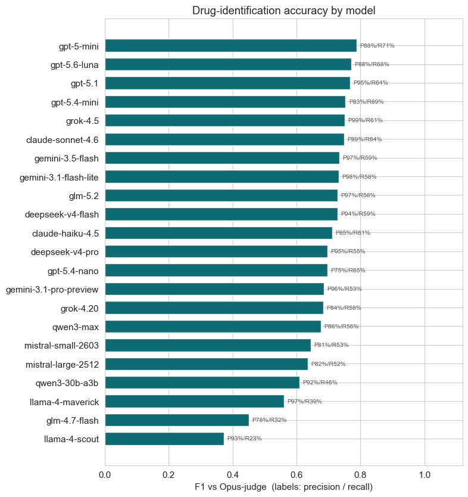

**Per-model correctness**

| model | F1 | precision | recall | string floor | drugs/post | $/1M in |
| --- | --- | --- | --- | --- | --- | --- |
| gpt-5-mini | 0.79 | 88% | 71% | 81% | 3.6 | $0.25 |
| gpt-5.6-luna | 0.77 | 88% | 68% | 76% | 3.5 | $1 |
| gpt-5.1 | 0.77 | 95% | 64% | 85% | 3.0 | $1.25 |
| gpt-5.4-mini | 0.75 | 83% | 69% | 87% | 3.7 | $0.75 |
| grok-4.5 | 0.75 | 99% | 61% | 97% | 2.8 | $2 |
| claude-sonnet-4.6 | 0.75 | 89% | 64% | 78% | 3.2 | $3 |
| gemini-3.5-flash | 0.73 | 97% | 59% | 96% | 2.7 | $1.5 |
| gemini-3.1-flash-lite | 0.73 | 98% | 58% | 93% | 2.7 | $0.25 |
| glm-5.2 | 0.73 | 97% | 58% | 94% | 2.7 | $0.909 |
| deepseek-v4-flash | 0.73 | 94% | 59% | 89% | 2.8 | $0.098 |
| claude-haiku-4.5 | 0.71 | 85% | 61% | 78% | 3.2 | $1 |
| deepseek-v4-pro | 0.70 | 95% | 55% | 89% | 2.6 | $0.435 |
| gpt-5.4-nano | 0.70 | 75% | 65% | 70% | 3.9 | $0.2 |
| gemini-3.1-pro-preview | 0.69 | 96% | 53% | 98% | 2.5 | $2 |
| grok-4.20 | 0.68 | 84% | 58% | 81% | 3.1 | $1.25 |
| qwen3-max | 0.68 | 86% | 56% | 78% | 2.9 | $0.78 |
| mistral-small-2603 | 0.64 | 81% | 53% | 79% | 3.0 | $0.15 |
| mistral-large-2512 | 0.63 | 82% | 52% | 73% | 2.8 | $0.5 |
| qwen3-30b-a3b | 0.61 | 92% | 46% | 92% | 2.2 | $0.12 |
| llama-4-maverick | 0.56 | 97% | 39% | 92% | 1.8 | $0.2 |
| glm-4.7-flash | 0.45 | 78% | 32% | 79% | 1.8 | $0.061 |
| llama-4-scout | 0.37 | 93% | 23% | 89% | 1.1 | $0.1 |

## 4. Counterintuitive: the precision–recall split

There is no single 'best extractor' — models sit on a tradeoff. Cautious models extract only the obvious drugs (high precision, low recall — they drop the ones needing inference); eager models grab everything drug-shaped (high recall, low precision — they hallucinate). Which end you want depends on whether a phantom report or a missed report costs the pipeline more.

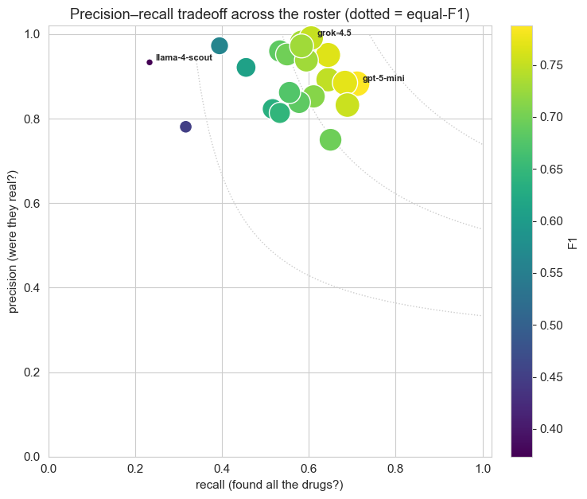

**What this shows:** models spread along the tradeoff, not a single quality axis. The most **precise** is **grok-4.5** (99%); the most **thorough** is **gpt-5-mini** (71%). For clustering, recall usually matters more — a missed drug is a missing data point — so a model in the high-recall corner with acceptable precision is the safer default.

## 5. Comparing the models to each other — divergence map

Mean Jaccard of extraction sets between every pair of models (1 = identical). It clusters the roster into behaviour groups and flags outliers — a diagnostic, never a correctness verdict (models can agree on the same misses).

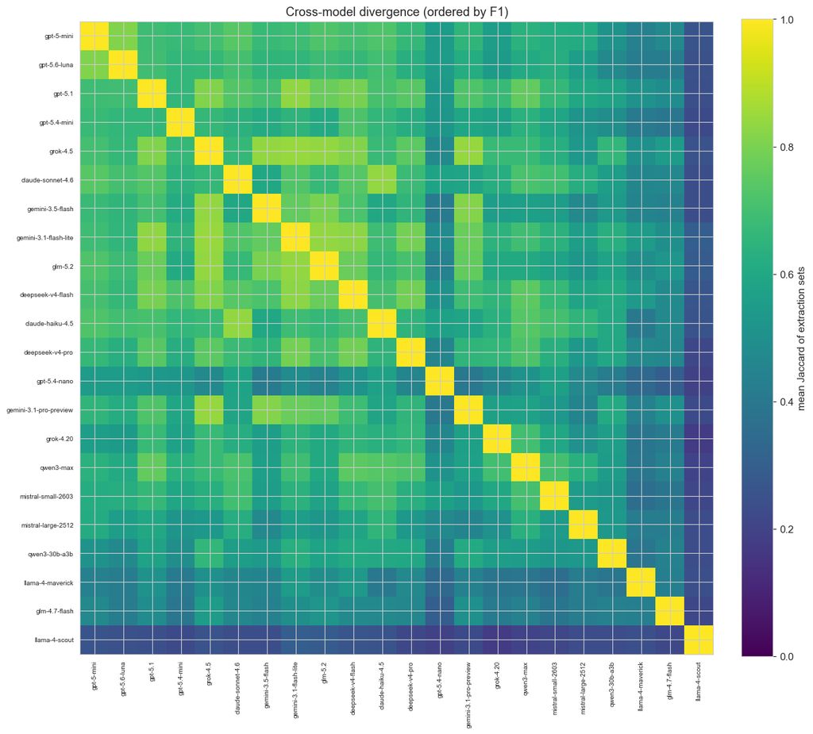

**Most divergent models**

| model | outlier (1 − mean agreement) | F1 |
| --- | --- | --- |
| llama-4-scout | 0.76 | 0.37 |
| llama-4-maverick | 0.57 | 0.56 |
| glm-4.7-flash | 0.56 | 0.45 |
| gpt-5.4-nano | 0.54 | 0.70 |
| mistral-large-2512 | 0.48 | 0.63 |
| qwen3-30b-a3b | 0.47 | 0.61 |
| grok-4.20 | 0.44 | 0.68 |
| mistral-small-2603 | 0.43 | 0.64 |

**What this shows:** the roster shares a mean **57%** extraction overlap — models genuinely differ on which borderline mentions count as drugs. Read outliers against §3: a divergent low-F1 model is a problem; a divergent high-F1 one just draws the drug boundary differently.

## 6. Conclusion & scorecard — F1 per dollar

The full scorecard and the design's payoff: the cheapest model whose accuracy is close to the best.

**② drug-ID — full scorecard**

| model | F1 | precision | recall | divergence | drugs/post | $/1M in |
| --- | --- | --- | --- | --- | --- | --- |
| gpt-5-mini | 0.79 | 88% | 71% | 0.38 | 3.6 | $0.25 |
| gpt-5.6-luna | 0.77 | 88% | 68% | 0.40 | 3.5 | $1 |
| gpt-5.1 | 0.77 | 95% | 64% | 0.34 | 3.0 | $1.25 |
| gpt-5.4-mini | 0.75 | 83% | 69% | 0.42 | 3.7 | $0.75 |
| grok-4.5 | 0.75 | 99% | 61% | 0.33 | 2.8 | $2 |
| claude-sonnet-4.6 | 0.75 | 89% | 64% | 0.37 | 3.2 | $3 |
| gemini-3.5-flash | 0.73 | 97% | 59% | 0.40 | 2.7 | $1.5 |
| gemini-3.1-flash-lite | 0.73 | 98% | 58% | 0.33 | 2.7 | $0.25 |
| glm-5.2 | 0.73 | 97% | 58% | 0.36 | 2.7 | $0.909 |
| deepseek-v4-flash | 0.73 | 94% | 59% | 0.33 | 2.8 | $0.098 |
| claude-haiku-4.5 | 0.71 | 85% | 61% | 0.37 | 3.2 | $1 |
| deepseek-v4-pro | 0.70 | 95% | 55% | 0.38 | 2.6 | $0.435 |
| gpt-5.4-nano | 0.70 | 75% | 65% | 0.54 | 3.9 | $0.2 |
| gemini-3.1-pro-preview | 0.69 | 96% | 53% | 0.40 | 2.5 | $2 |
| grok-4.20 | 0.68 | 84% | 58% | 0.44 | 3.1 | $1.25 |
| qwen3-max | 0.68 | 86% | 56% | 0.39 | 2.9 | $0.78 |
| mistral-small-2603 | 0.64 | 81% | 53% | 0.43 | 3.0 | $0.15 |
| mistral-large-2512 | 0.63 | 82% | 52% | 0.48 | 2.8 | $0.5 |
| qwen3-30b-a3b | 0.61 | 92% | 46% | 0.47 | 2.2 | $0.12 |
| llama-4-maverick | 0.56 | 97% | 39% | 0.57 | 1.8 | $0.2 |
| glm-4.7-flash | 0.45 | 78% | 32% | 0.56 | 1.8 | $0.061 |
| llama-4-scout | 0.37 | 93% | 23% | 0.76 | 1.1 | $0.1 |

Verdict

- **Best F1:** gpt-5-mini (0.79) — the accuracy anchor.

- **Precision and recall trade off** — pick the end that matches the cost of a phantom vs a missed report; for clustering, lean recall.

- **The string floor is too noisy to rank** (it misses correct paraphrases and counts non-treatment mentions), so Opus-as-judge is the standard here, not the floor.

## 7. Research limitations

- **The judge validation is weaker than ①.** RxNorm gave a clean external check on the alias judge; for ② the only objective anchor (string-in-post) is too loose, so we cannot cross-check Opus as tightly. A proper ② judge validation needs a second frontier model to review Opus's verdicts (the GT-review step, deferred).
- **Opus-as-truth is silver** — on genuinely ambiguous mentions ("an oral antibiotic", a drug named as a condition) it is a judgment, and it defines both the precision standard and the recall gold, so a systematic Opus blind spot would not show up here.
- **Posts** are 40 IRR-frame posts (100–800 chars); recall on longer, drug-denser posts may differ, and the frame excludes the corpus's long tail.
- **Price** is input $/1M and ignores output/latency — an order-of-magnitude signal.
- Measures the correctness of a measurement step, not any treatment effect.

**Provenance**

| item | value |
| --- | --- |
| run generated (UTC) | 2026-07-17T23:41:22.236310+00:00 |
| judgement | 2_drug_identification |
| candidate models | 22 (22 produced extractions) |
| judge (truth) | anthropic/claude-opus-4.8 |
| truth sources | string_in_post, opus_judge |
| posts | 40 |
| temperature | 0.0 |
| skill version | research-assistant v2 |

These findings reflect the behaviour of a measurement pipeline and model knowledge, not population-level treatment effects. This is not medical advice.